# Lab 8.4 - Using themes

# Plot themes

Customization is a crucial step to achieve appealing visual representations. As you have most likely already noticed, `ggplot` has its own *style*. That is, you can tell apart a basic ggplot from any other kind of representation. Luckily for us, we don’t have to stick to the *standard* theme. We can customize almost anything, though that implies becoming familiar with a large number of instructions. By now, we will show you alternative *ggplot themes* that have been predetermined and may suffice to remove the ugliness of our plots so far.

ggplot2 comes with a number of built in themes. The most important is `theme_grey()`, the signature ggplot2 theme with a light grey background and white gridlines. The theme is designed to put the data forward while supporting comparisons. We can still see the gridlines to aid in the judgement of position, but they have little visual impact and we can easily ‘tune’ them out. The grey background gives the plot a similar typographic colour to the text, ensuring that the graphics fit in with the flow of a document without jumping out with a bright white background. Finally, the grey background creates a continuous field of colour which ensures that the plot is perceived as a single visual entity.

- `theme_bw()`: a variation on `theme_grey()` that uses a white background and thin grey grid lines.
- `theme_linedraw()`: A theme with only black lines of various widths on white backgrounds, reminiscent of a line drawing.
- `theme_light()`: similar to `theme_linedraw()` but with light grey lines and axes, to direct more attention towards the data.
- `theme_dark()`: the dark cousin of `theme_light()`, with similar line sizes but a dark background. Useful to make thin coloured lines pop out.
- `theme_minimal()`: A minimalistic theme with no background annotations.
- `theme_classic()`: A classic-looking theme, with x and y axis lines and no gridlines.
- `theme_void()`: A completely empty theme.

Each one has it’s own style and it’s up to you to decide which one is closer to your needs. Don’t worry, even after assigning a theme we can keep customizing. In fact, these default themes are good starting point towards our own themes. Just invoke one of them at the end of the `ggplot` call and we are done.

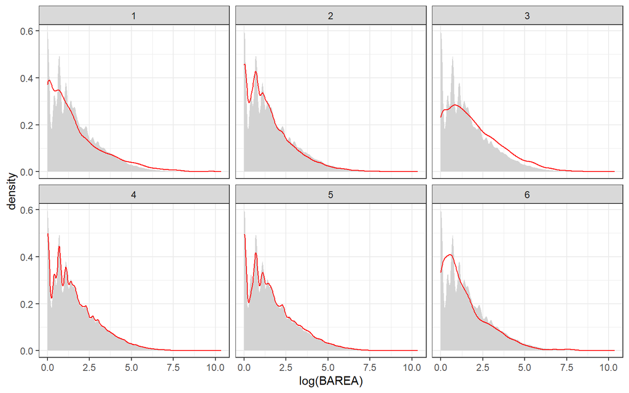

```r
fires %>%
    group_by(CAUSE) %>%
    ggplot() +
        geom_density(data=dplyr::select(fires,-CAUSE), aes(x=log(BAREA)),fill='lightgrey', color =NA) + #all fires without MONTH
        geom_density(aes(x=log(BAREA)), color ='red') +
        facet_wrap(~CAUSE) +
    theme_bw()
```

## Getting additional themes

Same as color scales, several developers invested some time to create specific themes. The package `ggthemes` is a good example. It includes a collection of predifined themes *mimicking* the style of some of the most famous journals.

You can take a quick tour in https://yutannihilation.github.io/allYourFigureAreBelongToUs/ggthemes/.

## Setting up our own theme

Despite of the wide array of themes that we can get, it is normally the case we want to set up our own theme. That is particularly important when we are involved in a scientific document and we need to produce similar figures in terms of style.

To do so we can create our theme, and then call it in ggplot same as any other. The following chunk of code provides an example. Rather than starting from the scratch we take the `theme_bw` as basis and then customize it.

```r
newtheme <- theme_bw() + theme(panel.grid.major.x = element_blank(), panel.grid.minor.x = element_blank(),
    panel.background = element_rect(color = "white"), axis.text.x = element_text(face = "bold",
        size = 7, vjust = 0.5, angle = 0))
```

Once we got the theme we just add it to a plot:

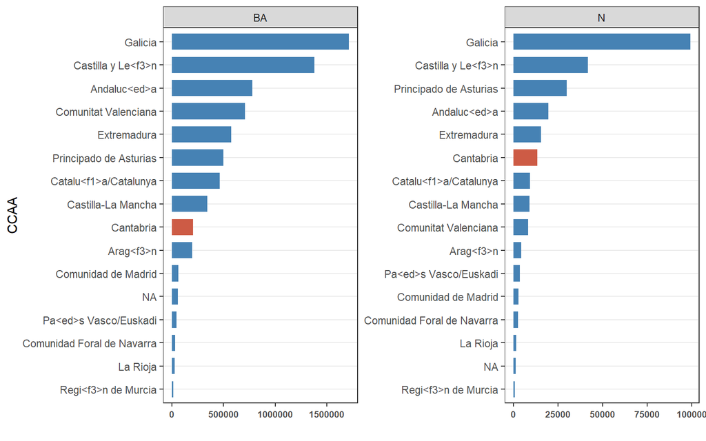

```r
library(tidytext)

# Getting data for Cantabria alone
d <- fires %>%
    filter(CCAA == "Cantabria") %>%
    group_by(CCAA) %>%
    summarise(N = n(), BA = sum(BAREA)) %>%
    pivot_longer(cols = c(N:BA), names_to = "var", values_to = "value") %>%
    ungroup() %>%
    # reorder_within allows sorting per group
mutate(CCAA = reorder_within(CCAA, value, var))

# Getting data for all CCAA and plotting
fires %>%
    group_by(CCAA) %>%
    summarise(N = n(), BA = sum(BAREA)) %>%
    pivot_longer(cols = c(N:BA), names_to = "var", values_to = "value") %>%
    ungroup() %>%
    mutate(CCAA = reorder_within(CCAA, value, var)) %>%
    ggplot() + geom_col(aes(y = reorder(CCAA, value), x = round(value, 0), group = var),
    fill = "steelblue", width = 0.7) + geom_col(data = d, aes(y = reorder(CCAA, value),
    x = round(value, 0), group = var), fill = "coral3", width = 0.7) + scale_y_reordered(name = "CCAA") +
    labs(x = "") + facet_wrap(~var, scales = "free") + newtheme
```

> Note that when calling our own theme we **do not use parenthesis**.

So far so good. But, how can we manipulate the elements of a plot.? To modify an individual theme component you use code like `plot + theme(element.name = element_function())`. In this section you’ll learn about the basic element functions, and then in the next section, you’ll see all the elements that you can modify.

There are four basic types of built-in element functions: text, lines, rectangles, and blank. Each element function has a set of parameters that control the appearance:

- `element_text()` draws labels and headings. You can control the font `family`, `face`, `colour`, `size` (in points), `hjust`, `vjust`, `angle` (in degrees) and `lineheight` (as ratio of `fontcase`). More details on the parameters can be found in `vignette("ggplot2-specs")`.

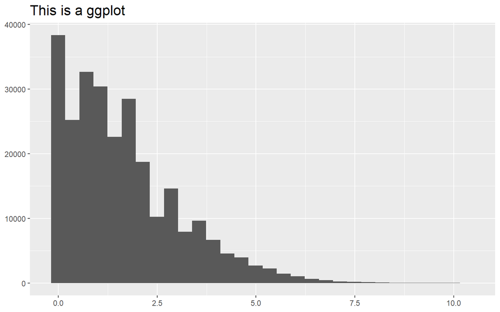

```r
base <- ggplot(fires, aes(x = log(BAREA))) + geom_histogram()
base_t <- base + labs(title = "This is a ggplot") + xlab(NULL) + ylab(NULL)
base_t + theme(plot.title = element_text(size = 16))
```

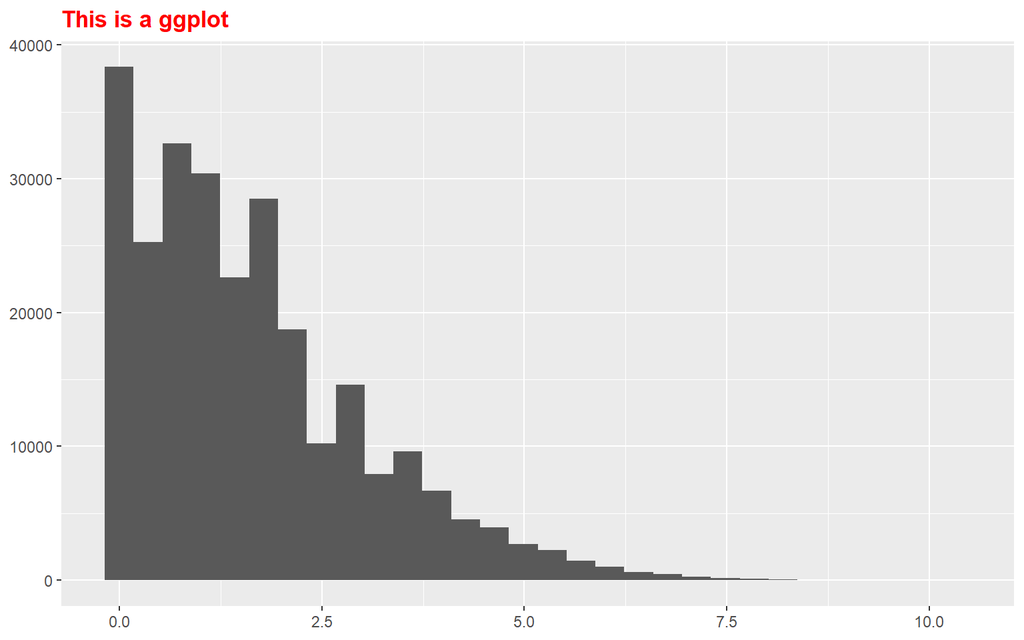

```r
base_t + theme(plot.title = element_text(face = "bold", colour = "red"))
```

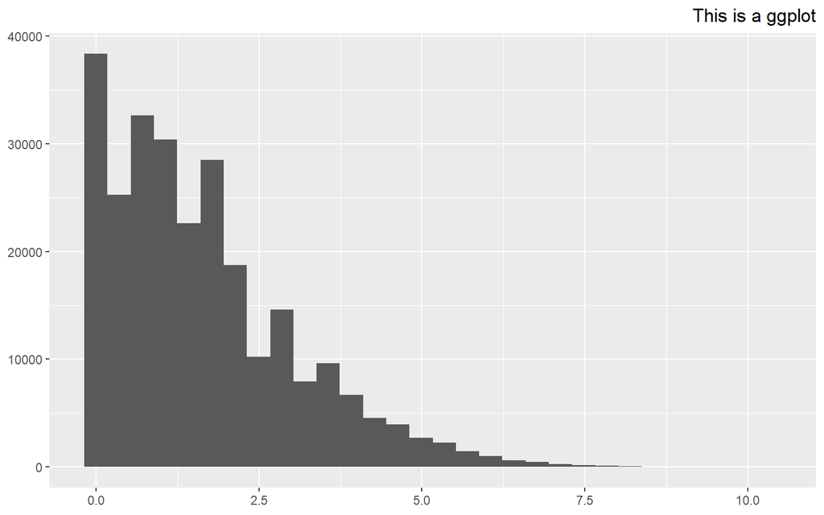

```r
base_t + theme(plot.title = element_text(hjust = 1))
```

You can control the margins around the text with the `margin` argument and`margin()` function. `margin()` has four arguments: the amount of space (in points) to add to the top, right, bottom and left sides of the text. Any elements not specified default to 0.

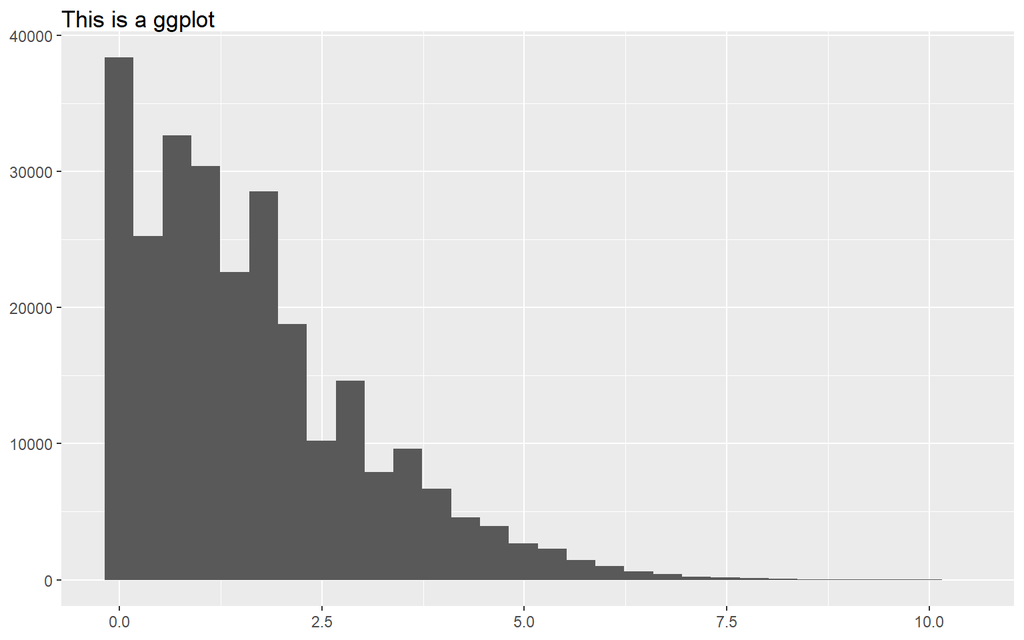

```r
# The margins here look asymmetric because there are also plot margins
base_t + theme(plot.title = element_text(margin = margin()))
```

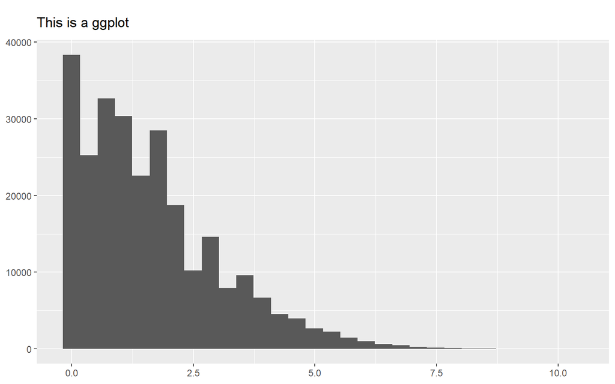

```r
base_t + theme(plot.title = element_text(margin = margin(t = 10, b = 10)))
```

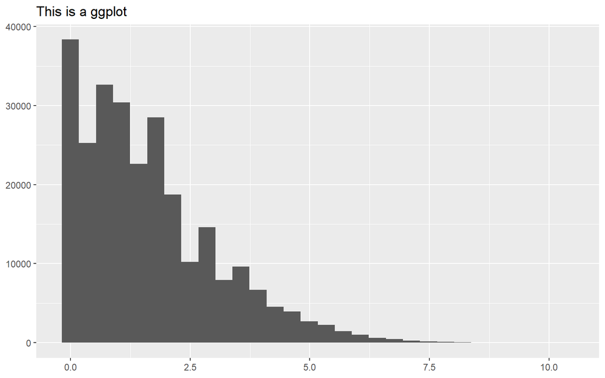

```r
base_t + theme(axis.title.y = element_text(margin = margin(r = 10)))
```

- `element_line()` draws lines parameterised by `colour`, `size` and `linetype`:

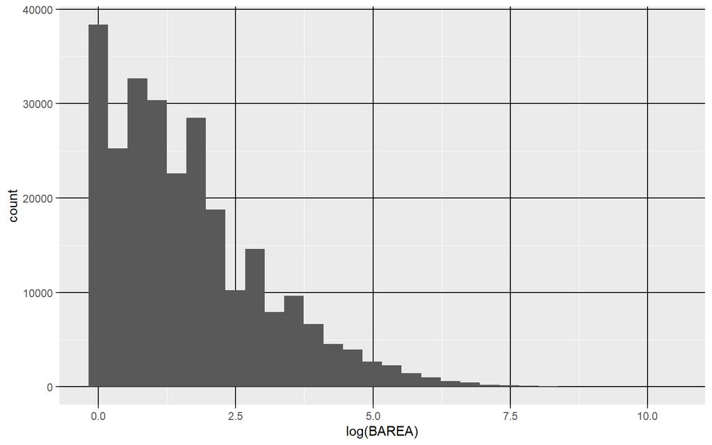

```r
base + theme(panel.grid.major = element_line(colour = "black"))
```

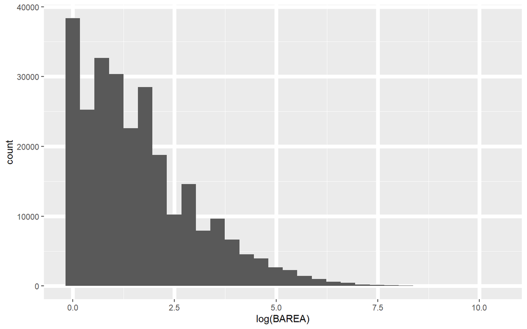

```r
base + theme(panel.grid.major = element_line(size = 2))
```

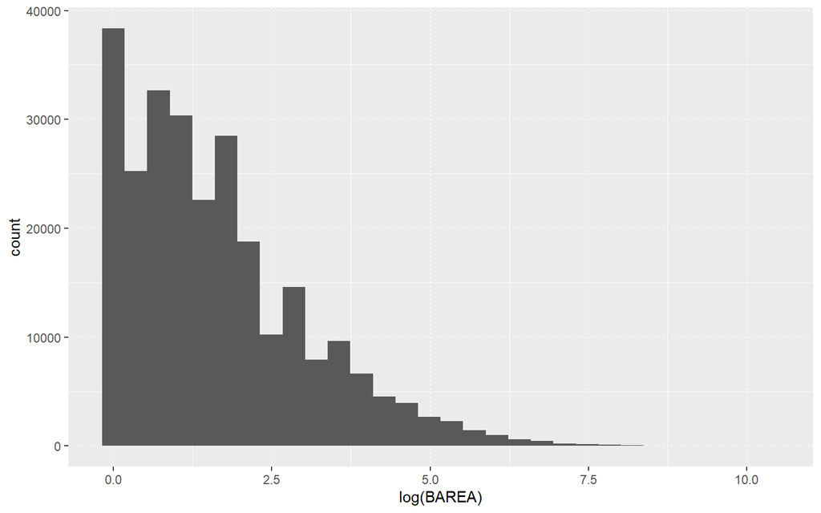

```r
base + theme(panel.grid.major = element_line(linetype = "dotted"))
```

- `element_rect()` draws rectangles, mostly used for backgrounds, parameterised by `fill` colour and border `colour`, `size` and `linetype`.

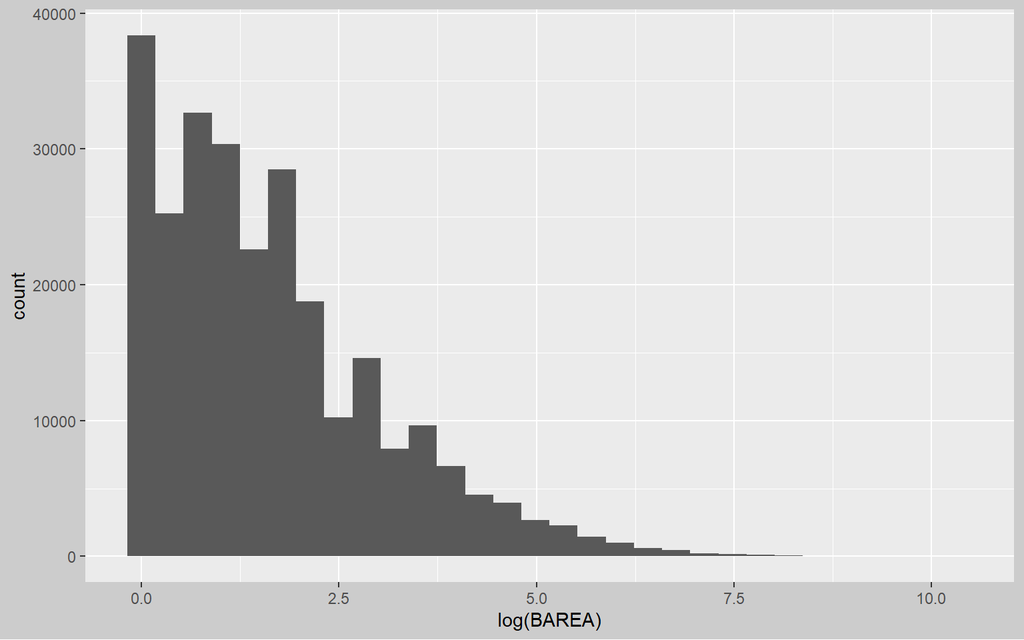

```r
base + theme(plot.background = element_rect(fill = "grey80", colour = NA))
```

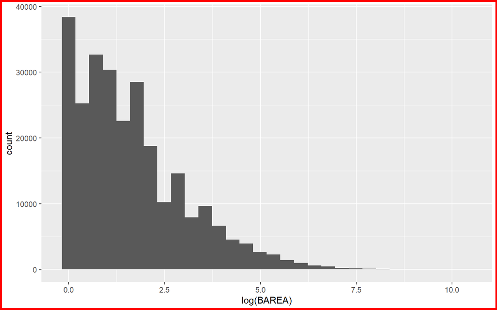

```r
base + theme(plot.background = element_rect(colour = "red", size = 2))
```

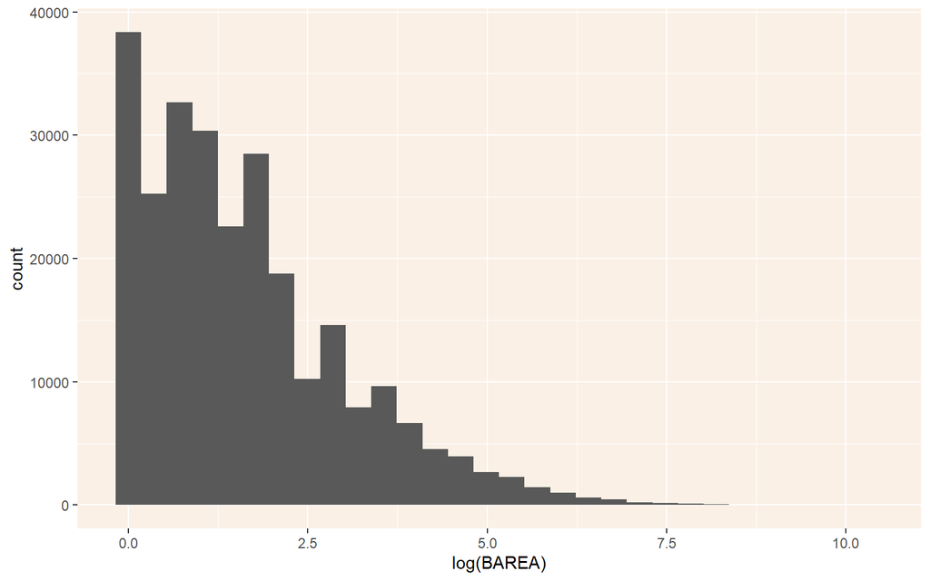

```r
base + theme(panel.background = element_rect(fill = "linen"))
```

- `element_blank()` draws nothing. Use this if you don’t want anything drawn, and no space allocated for that element. The following example uses `element_blank()` to progressively suppress the appearance of elements we’re not interested in. Notice how the plot automatically reclaims the space previously used by these elements: if you don’t want this to happen (perhaps because they need to line up with other plots on the page), use `colour = NA, fill = NA` to create invisible elements that still take up space.

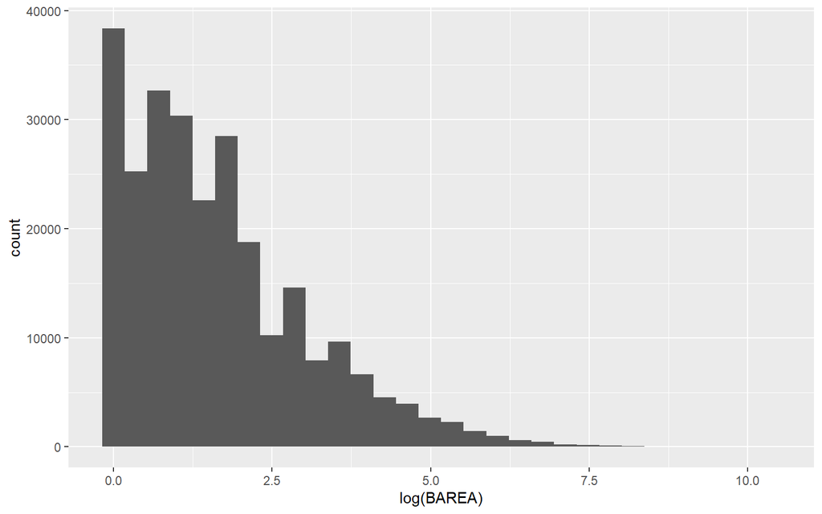

```r
base
```

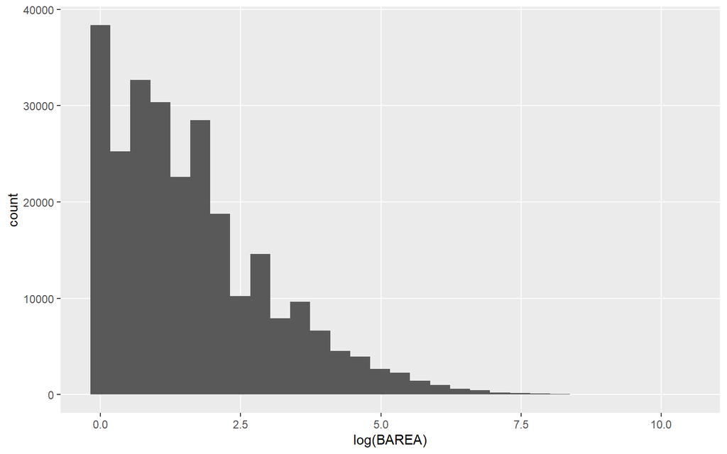

```r
last_plot() + theme(panel.grid.minor = element_blank())
```

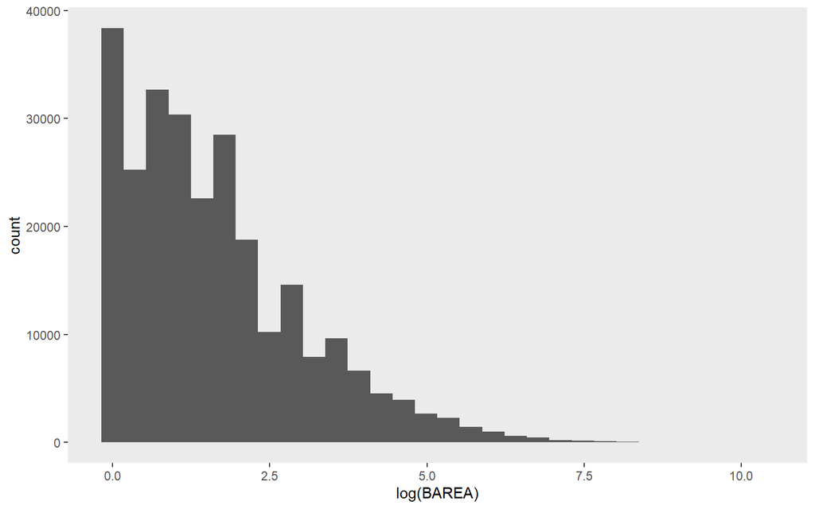

```r
last_plot() + theme(panel.grid.major = element_blank())
```

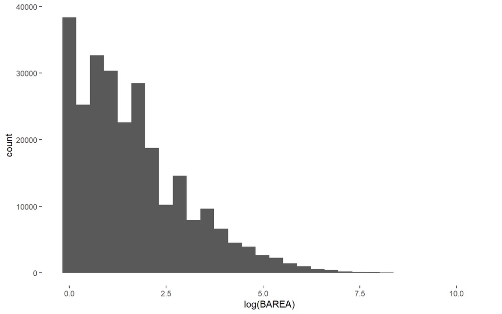

```r
last_plot() + theme(panel.background = element_blank())
```

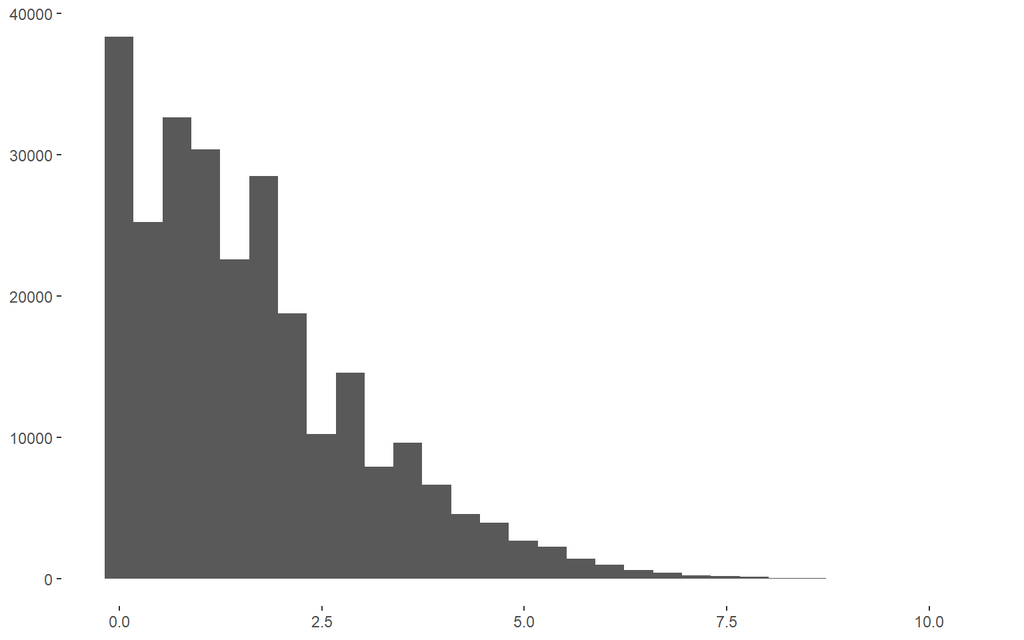

```r
last_plot() + theme(axis.title.x = element_blank(), axis.title.y = element_blank())
```

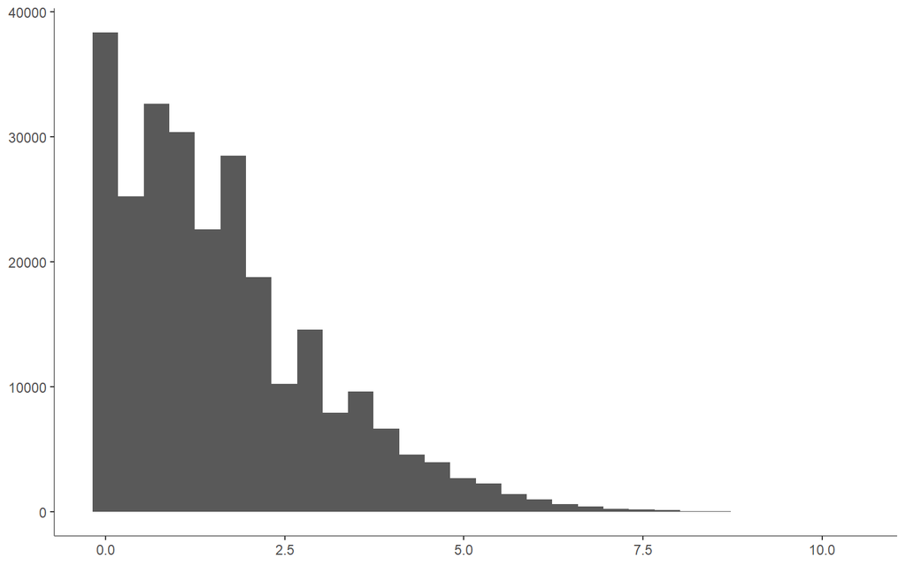

```r
last_plot() + theme(axis.line = element_line(colour = "grey50"))
```

- A few other settings take grid units. Create them with `unit(1, "cm")` or `unit(0.25, "in")`.

To modify theme elements for all future plots, use `theme_update()`. It returns the previous theme settings, so you can easily restore the original parameters once you’re done.

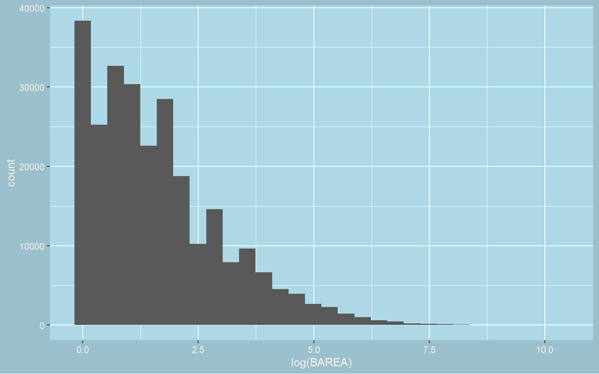

```r
old_theme <- theme_update(plot.background = element_rect(fill = "lightblue3", colour = NA),
    panel.background = element_rect(fill = "lightblue", colour = NA), axis.text = element_text(colour = "linen"),
    axis.title = element_text(colour = "linen"))
base
```

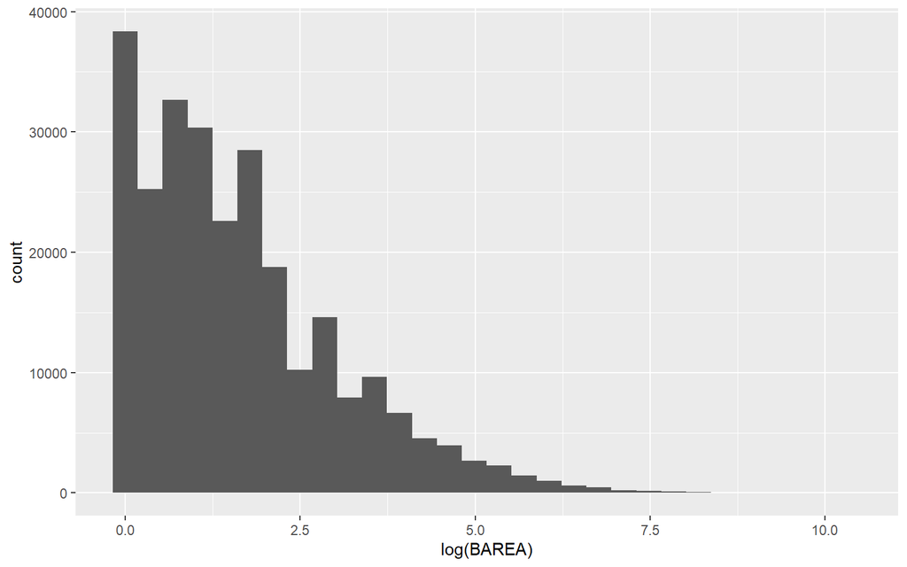

```r
theme_set(old_theme)
base
```

## Theme elements

There are around 40 unique elements that control the appearance of the plot. They can be roughly grouped into five categories: plot, axis, legend, panel and facet. The following sections describe each in turn.

### Plot elements

Some elements affect the plot as a whole:

| Element | Setter | Description |
| --- | --- | --- |
| plot.background | `element_rect()` | plot background |
| plot.title | `element_text()` | plot title |
| plot.margin | `margin()` | margins around plot |

`plot.background` draws a rectangle that underlies everything else on the plot. By default, ggplot2 uses a white background which ensures that the plot is usable wherever it might end up (e.g. even if you save as a png and put on a slide with a black background). When exporting plots to use in other systems, you might want to make the background transparent with `fill = NA`. Similarly, if you’re embedding a plot in a system that already has margins you might want to eliminate the built-in margins. Note that a small margin is still necessary if you want to draw a border around the plot.

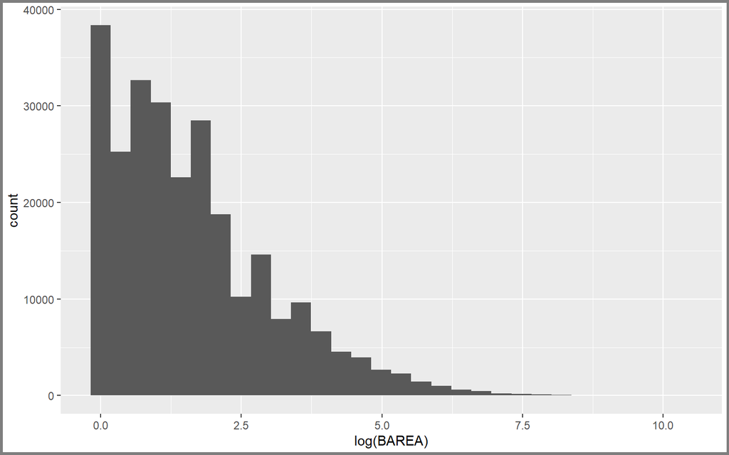

```r
base + theme(plot.background = element_rect(colour = "grey50", size = 2))
```

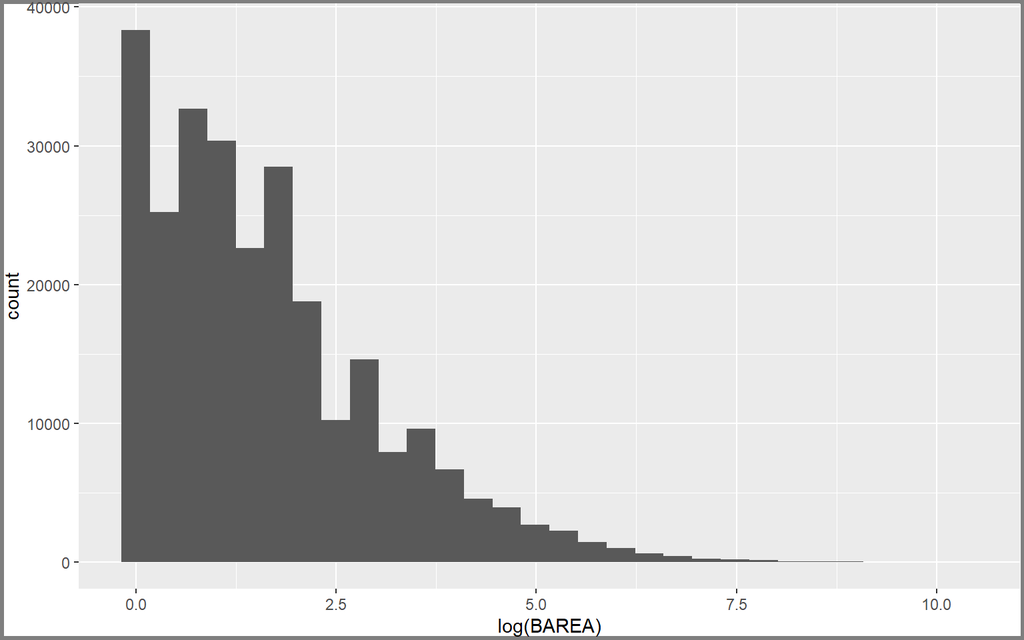

```r
base + theme(plot.background = element_rect(colour = "grey50", size = 2), plot.margin = margin(2,
    2, 2, 2))
```

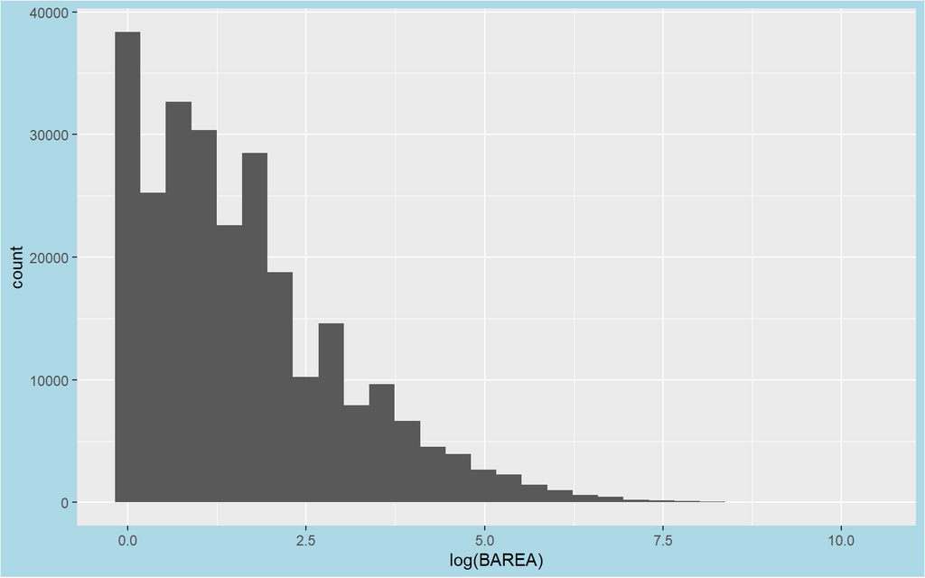

```r
base + theme(plot.background = element_rect(fill = "lightblue"))
```

### Axis elements

The axis elements control the apperance of the axes:

| Element | Setter | Description |
| --- | --- | --- |
| axis.line | `element_line()` | line parallel to axis (hidden in default themes) |
| axis.text | `element_text()` | tick labels |
| axis.text.x | `element_text()` | x-axis tick labels |
| axis.text.y | `element_text()` | y-axis tick labels |
| axis.title | `element_text()` | axis titles |
| axis.title.x | `element_text()` | x-axis title |
| axis.title.y | `element_text()` | y-axis title |
| axis.ticks | `element_line()` | axis tick marks |
| axis.ticks.length | `unit()` | length of tick marks |

Note that `axis.text` (and `axis.title`) comes in three forms: `axis.text`, `axis.text.x`, and `axis.text.y`. Use the first form if you want to modify the properties of both axes at once: any properties that you don’t explicitly set in `axis.text.x` and `axis.text.y` will be inherited from `axis.text`.

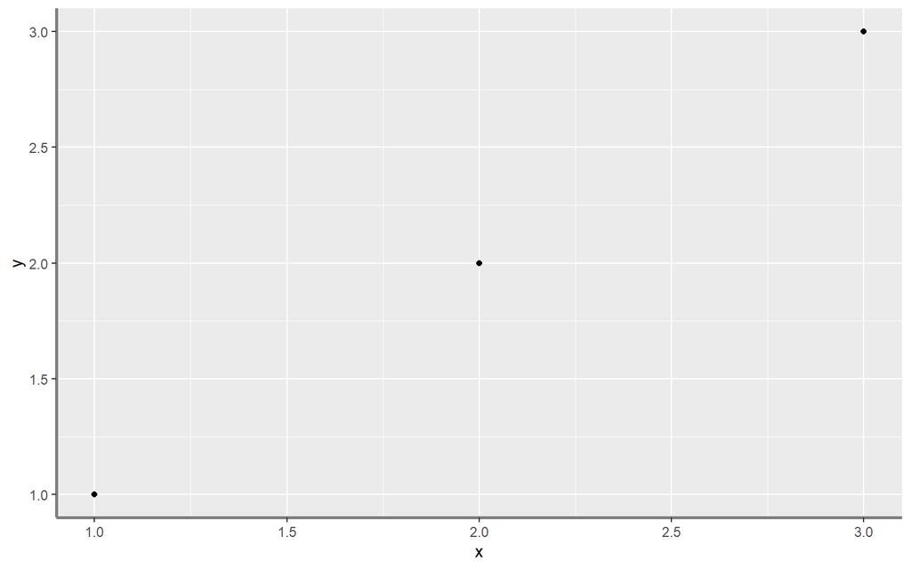

```r
df <- data.frame(x = 1:3, y = 1:3)
base <- ggplot(df, aes(x, y)) + geom_point()
# Accentuate the axes
base + theme(axis.line = element_line(colour = "grey50", size = 1))
```

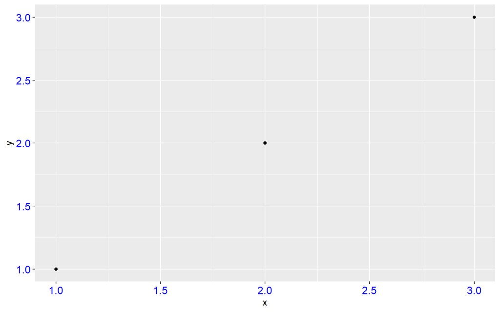

```r
# Style both x and y axis labels
base + theme(axis.text = element_text(color = "blue", size = 12))
```

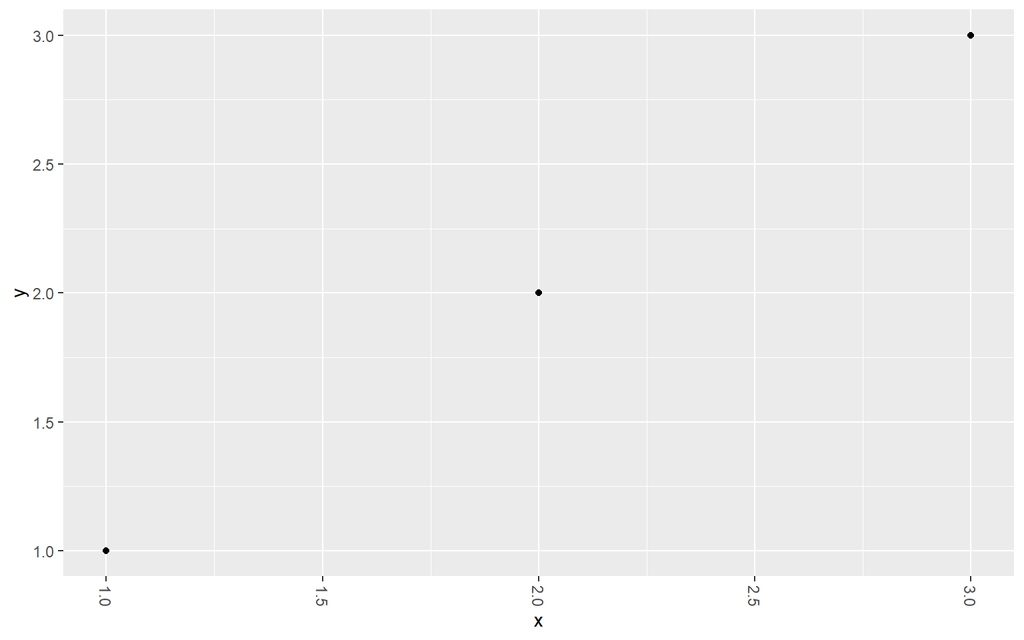

```r
# Useful for long labels
base + theme(axis.text.x = element_text(angle = -90, vjust = 0.5))
```

The most common adjustment is to rotate the x-axis labels to avoid long overlapping labels. If you do this, note negative angles tend to look best and you should set `hjust = 0` and `vjust = 1`:

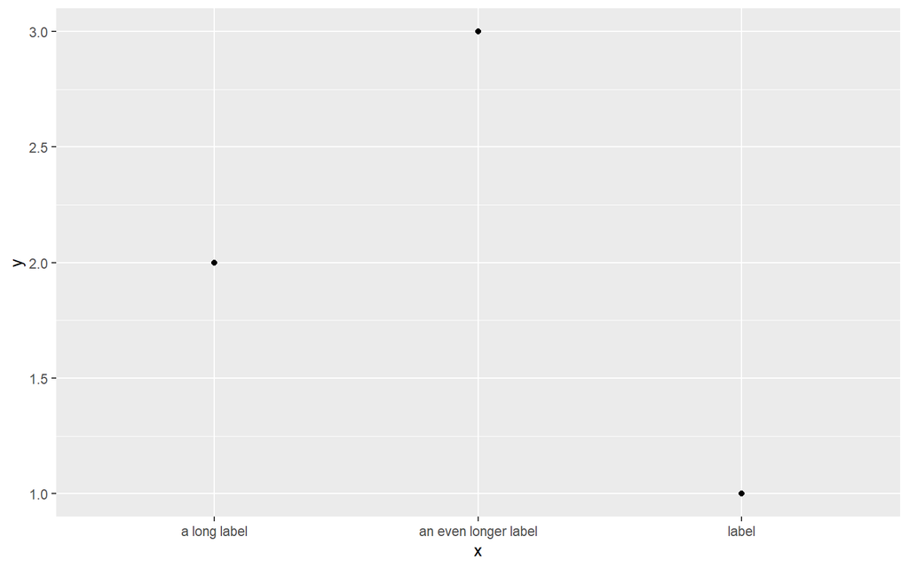

```r
df <- data.frame(x = c("label", "a long label", "an even longer label"), y = 1:3)
base <- ggplot(df, aes(x, y)) + geom_point()
base
```

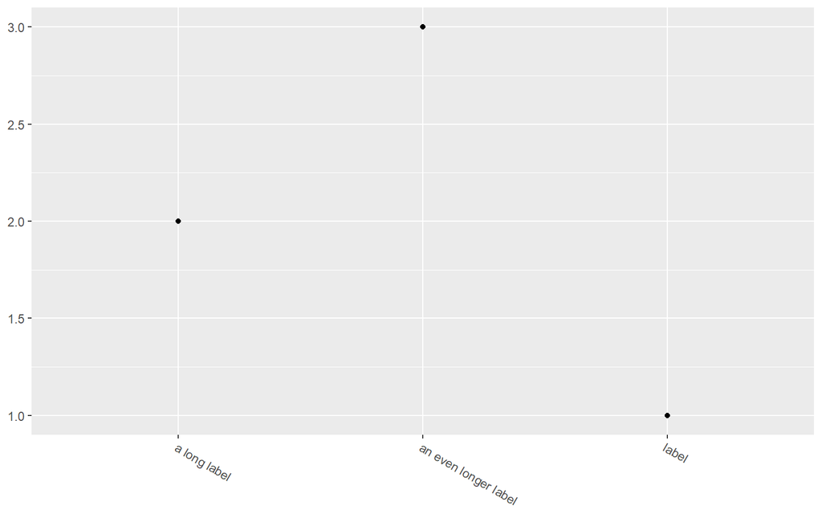

```r
base + theme(axis.text.x = element_text(angle = -30, vjust = 1, hjust = 0)) + xlab(NULL) +
    ylab(NULL)
```